# Bioinformatics

### Clusterisation of the main conformation of proteins

##### Viktoria Ivanova - 7MI3400799

In this project, advanced research on the polypeptide chains will be held, as them being the main construction unit of the proteins. Their possible conformations will be investigated by clustering the phi and psi combinations of rotations, as some of them are more favourable and others are not possible to happen in the polypeptide chain at all.

### Imports

```python
import numpy as np
import pandas as pd
import matplotlib.pyplot as plt
from sklearn.cluster import KMeans
from sklearn.cluster import DBSCAN
from sklearn.neighbors import NearestNeighbors
```

##### Loading the data

```python
proteins_df = pd.read_csv("data_assignment3.csv")
proteins_df
```

|  | residue name | position | chain | phi | psi |
| --- | --- | --- | --- | --- | --- |
| 0 | LYS | 10 | A | -149.312855 | 142.657714 |
| 1 | PRO | 11 | A | -44.283210 | 136.002076 |
| 2 | LYS | 12 | A | -119.972621 | -168.705263 |
| 3 | LEU | 13 | A | -135.317212 | 137.143523 |
| 4 | LEU | 14 | A | -104.851467 | 95.928520 |
| ... | ... | ... | ... | ... | ... |
| 29364 | GLY | 374 | B | -147.749557 | 155.223562 |
| 29365 | GLN | 375 | B | -117.428541 | 133.019506 |
| 29366 | ILE | 376 | B | -113.586448 | 112.091970 |
| 29367 | ASN | 377 | B | -100.668779 | -12.102821 |
| 29368 | LYS | 378 | B | -169.951240 | 94.233680 |

29369 rows × 5 columns

```python
proteins_df.dtypes
```

```
residue name     object
position          int64
chain            object
phi             float64
psi             float64
dtype: object
```

We can conclude that there are 5 features, 2 of them are categorical - 'Residue name' and 'Chain' and the other 3 are numerical - the position of the aminoacid and the phi and psi angles, presented in degrees.

1. Show the distribution of phi and psi combinations using:

   a. A scatter plot

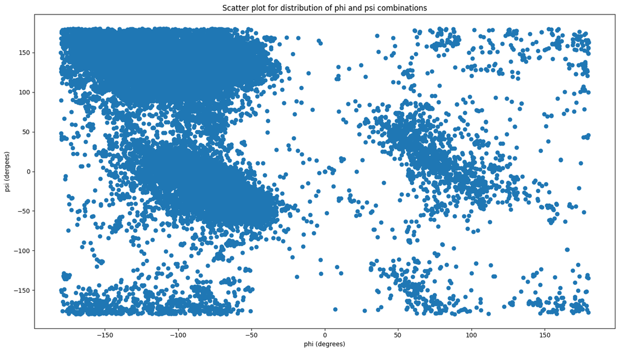

```python
plt.figure(figsize=(14,8))
plt.scatter(proteins_df['phi'], proteins_df['psi'])
plt.xlabel(f'phi (degrees)')
plt.ylabel('psi (dergees)')
plt.title('Scatter plot for distribution of phi and psi combinations')

plt.tight_layout()
plt.show()
```

We can see 7 more divided clusters, but depending on the algorithm used, they can be less.

b. A 2D histogram

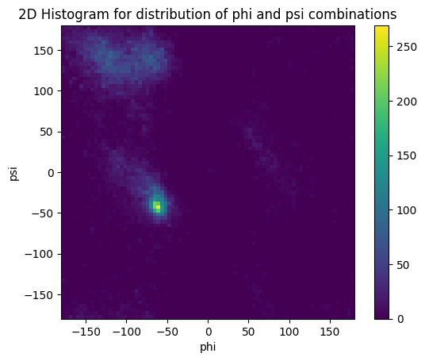

```python
plt.hist2d(proteins_df['phi'], proteins_df['psi'], bins=80)
plt.xlabel("phi")
plt.ylabel("psi")
plt.title("2D Histogram for distribution of phi and psi combinations")
plt.colorbar()
plt.gca().set_aspect('equal')
```

Here, only 3 clusters are outstandingly visible, although, 5 can be seen as well.

Here we can also check the distribution of separate phi and psi componenents to see outstanding number of samples for a specific diapason:

```
Mean value for phi : -82.362
Median value for phi : -85.198
Standard deviation for phi : 56.847
```

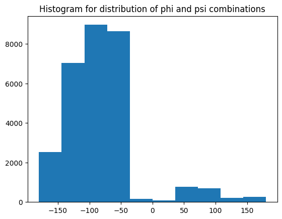

```
Mean value for psi : 64.252
Median value for psi : 110.903
Standard deviation for psi : 91.118
```

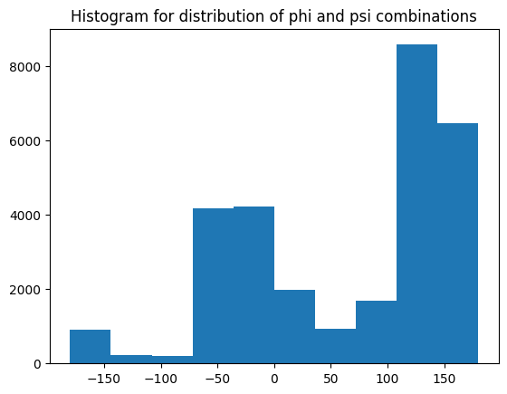

```python
for label, data in proteins_df.items():
    if data.dtypes != 'object' and label != 'position':
        print(f'Mean value for {label} : {np.round(np.mean(data), 3)}')
        print(f'Median value for {label} : {np.round(np.median(data), 3)}')
        print(f'Standard deviation for {label} : {np.round(np.std(data), 3)}')

        plt.title("Histogram for distribution of phi and psi combinations")
        plt.hist(data, bins=10)
        plt.show()

    print()
```

2. Use the K-means clustering method to cluster the phi and psi angle combinations in the data file

```python
clustering_proteins_df = proteins_df[['phi', 'psi']]
clustering_proteins_df
```

|  | phi | psi |
| --- | --- | --- |
| 0 | -149.312855 | 142.657714 |
| 1 | -44.283210 | 136.002076 |
| 2 | -119.972621 | -168.705263 |
| 3 | -135.317212 | 137.143523 |
| 4 | -104.851467 | 95.928520 |
| ... | ... | ... |
| 29364 | -147.749557 | 155.223562 |
| 29365 | -117.428541 | 133.019506 |
| 29366 | -113.586448 | 112.091970 |
| 29367 | -100.668779 | -12.102821 |
| 29368 | -169.951240 | 94.233680 |

29369 rows × 2 columns

Based on the inertia, we can deside the best number of clusters.

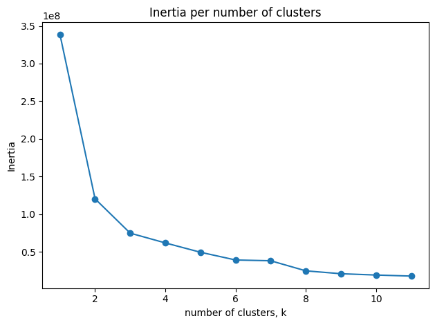

```python
clusters = np.arange(1, 12)
inertia_list = []

for num_clusters in clusters:
    kmeans = KMeans(n_clusters=num_clusters)
    kmeans.fit(clustering_proteins_df)
    inertia_list.append(kmeans.inertia_)

plt.plot(clusters, inertia_list)
plt.scatter(clusters, inertia_list)
plt.title('Inertia per number of clusters')
plt.xlabel('number of clusters, k')
plt.ylabel('Inertia')
plt.tight_layout()
plt.show()
```

Based in the plot, we can assume that 3 is a good number of clusters, because after that, the inertia is not becoming signifficantly smaller.

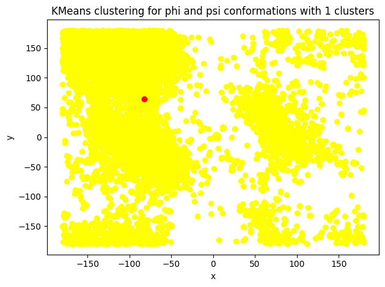

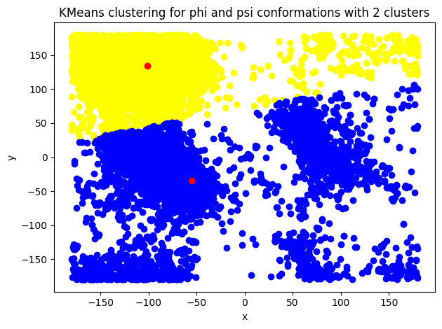

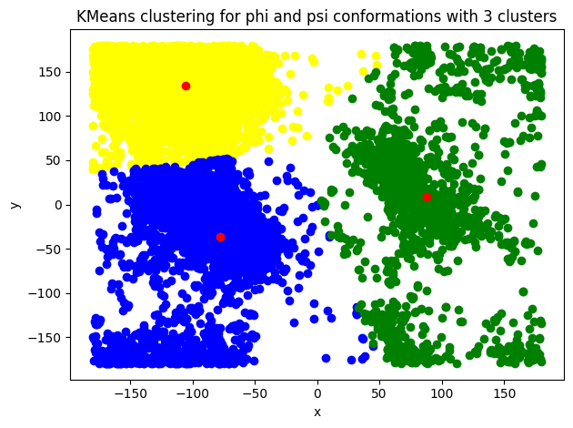

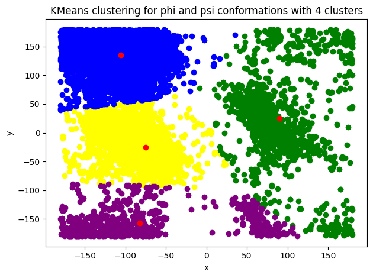

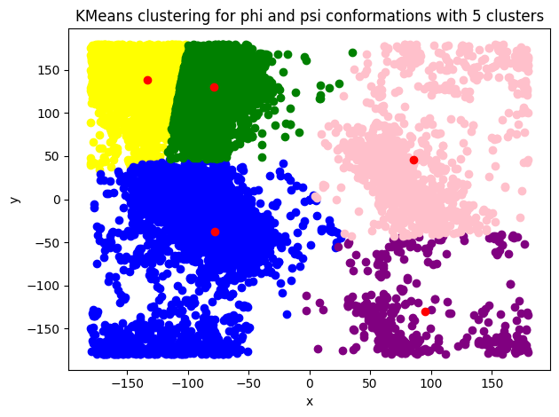

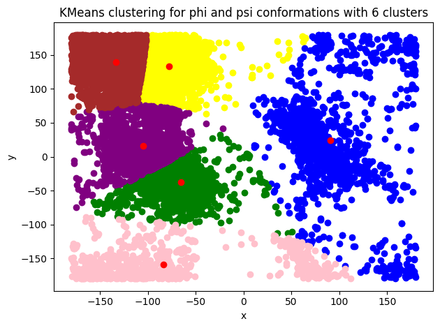

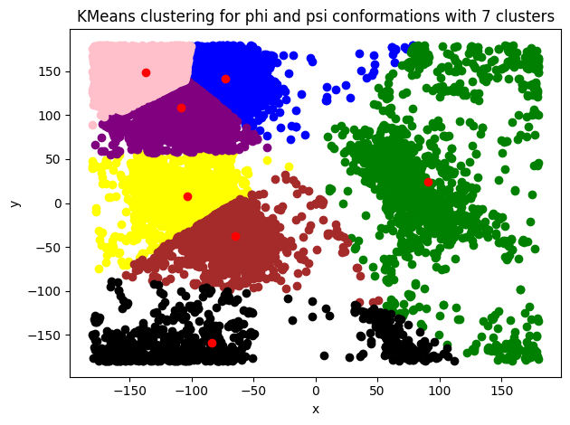

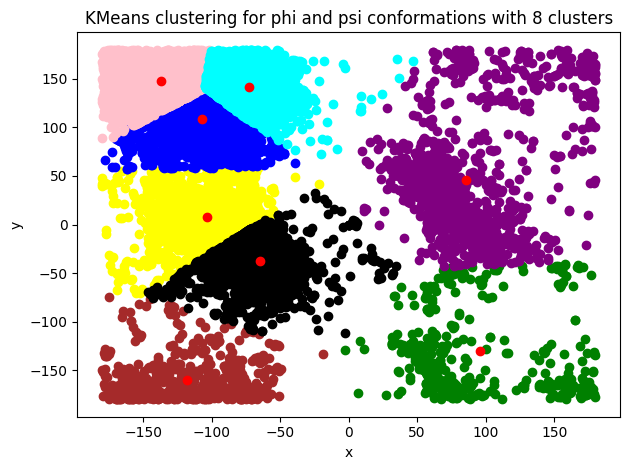

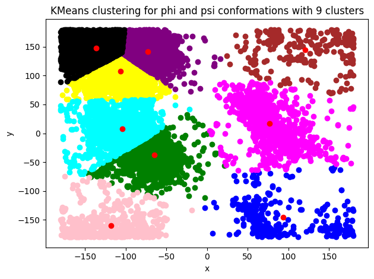

```python
clustering_proteins_df_kmeans = np.array(clustering_proteins_df)

colors = ['yellow', 'blue', 'green', 'purple', 'pink', 'brown', 'black', 'cyan', 'magenta']

for num_clusters in range(1, 10):
    km = KMeans(n_clusters=num_clusters)
    label = km.fit_predict(clustering_proteins_df_kmeans)

    for curr_label in range(num_clusters):
        filtered_label = clustering_proteins_df_kmeans[label == curr_label]
        plt.scatter(filtered_label[:,0] , filtered_label[:,1] , color = colors[curr_label])

    centroids = km.cluster_centers_
    plt.scatter(centroids[:,0] , centroids[:,1], color='red')
    plt.title(f'KMeans clustering for phi and psi conformations with {num_clusters} clusters')
    plt.xlabel('x')
    plt.ylabel('y')
    plt.tight_layout()
    plt.show()
```

a. Experiment with different values of K. Suggest an appropriate value of K for this task and motivate this choice.

Based on the K means algorithm and also on the inertia plot, we can conclude that the best number of clusters should be 3. Unlike the assumption from the scatter plot, some of the border areas look like a separate cluster but K means is deciding them better as part of other cluster.

b. Do the clusters found in part (a) seem reasonable?

3. Use the DBSCAN method to cluster the phi and psi angle combinations in the data file.

```python
clustering_proteins_df_dbscan = proteins_df[['phi', 'psi']].values
clustering_proteins_df_dbscan
```

```
array([[-149.312855,  142.657714],
       [ -44.28321 ,  136.002076],
       [-119.972621, -168.705263],
       ...,
       [-113.586448,  112.09197 ],
       [-100.668779,  -12.102821],
       [-169.95124 ,   94.23368 ]])
```

a. Motivate the choice of:

i. the minimum number of samples in the neighbourhood for a point to be considered as a core point, and

ii. the maximum distance between two samples belonging to the same neighbourhood (“eps” or “epsilon”).

1. the minimum number of samples in the neighbourhood for a point to be considered as a core point - we will choose it as the number_of_features * 2
2. epsilon should be the maximum distance between two samples belonging to the same neighbourhood. Let's now choose the epsilon value:

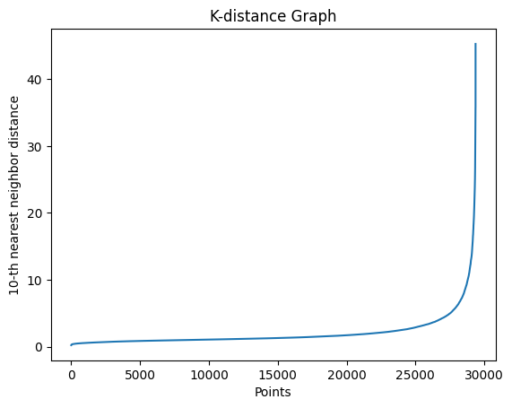

```python
neighbour = NearestNeighbors(n_neighbors=10)
neighbour.fit(clustering_proteins_df_dbscan)
distances, _ = neighbour.kneighbors(clustering_proteins_df_dbscan)
distances = np.sort(distances[:, 9])

plt.plot(distances)
plt.xlabel('Points')
plt.ylabel(f'10-th nearest neighbor distance')

plt.title('K-distance Graph')
plt.show()
```

```python
epsilon = np.percentile(distances, 90)
epsilon
```

```
3.7215470442338865
```

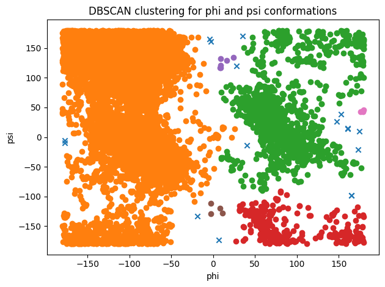

```python
epsilon = 15
min_num_samples = 4

db = DBSCAN(eps=epsilon, min_samples=min_num_samples)
db_labels = db.fit_predict(clustering_proteins_df_dbscan)
proteins_df["dbscan_cluster"] = db_labels

unique_labels = np.unique(db_labels)

for label in unique_labels:
    subset = proteins_df[proteins_df["dbscan_cluster"] == label]
    if label == -1:
        plt.scatter(subset["phi"], subset["psi"], marker="x")
    else:
        plt.scatter(subset["phi"], subset["psi"])

plt.xlabel("phi")
plt.ylabel("psi")
plt.title("DBSCAN clustering for phi and psi conformations")

plt.tight_layout()
plt.show()
```

Compare the clusters found by DBSCAN with those found using K-means.

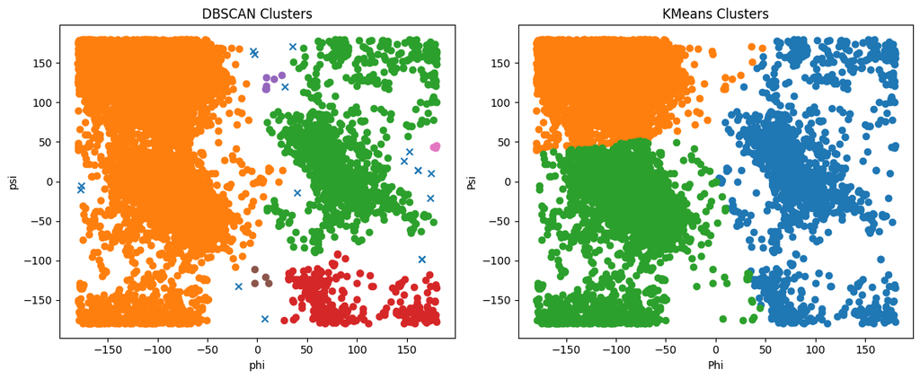

```python
kmeans = KMeans(n_clusters=3)
proteins_df["kmeans_cluster"] = kmeans.fit_predict(clustering_proteins_df_dbscan)

fig, axes = plt.subplots(1, 2, figsize=(12, 5))

ax = axes[0]
unique = np.unique(db_labels)

for label in unique:
    subset = proteins_df[proteins_df["dbscan_cluster"] == label]
    if label == -1:
        ax.scatter(subset["phi"], subset["psi"], marker="x")
    else:
        ax.scatter(subset["phi"], subset["psi"])

ax.set_title("DBSCAN Clusters")
ax.set_xlabel("phi")
ax.set_ylabel("psi")

ax = axes[1]
unique_km = np.unique(proteins_df["kmeans_cluster"])

for label in unique_km:
    subset = proteins_df[proteins_df["kmeans_cluster"] == label]
    ax.scatter(subset["phi"], subset["psi"])

ax.set_title("KMeans Clusters")
ax.set_xlabel("Phi")
ax.set_ylabel("Psi")

plt.tight_layout()
plt.show()
```

From my point of view, DBSCAN algorithm is clustering them more accurately, based on the visible results.

b. Highlight the clusters found using DBSCAN and any outliers in a scatter plot

c. How many outliers are found? Plot a bar chart to show how often each of the amino acid residue types are outliers

```
Number of outliers: 17
```

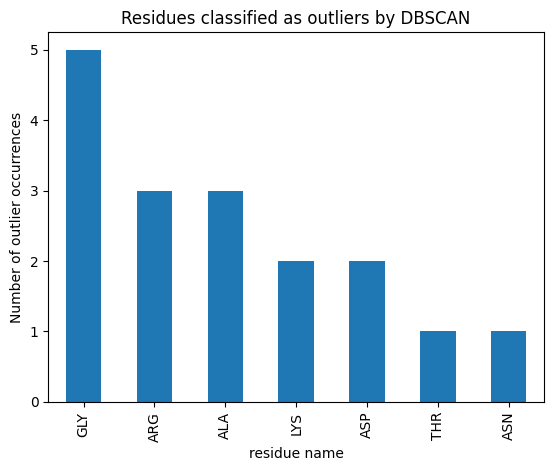

```python
outliers = proteins_df[proteins_df["dbscan_cluster"] == -1]
n_outliers = len(outliers)
print("Number of outliers:", n_outliers)

counts = outliers["residue name"].value_counts()

counts.plot(kind="bar")
plt.ylabel("Number of outlier occurrences")
plt.title("Residues classified as outliers by DBSCAN")
plt.show()
```

4. The data file can be stratified by amino acid residue type. Use DBSCAN to cluster the data that have residue type PRO. Investigate how the clusters found for amino acid residues of type PRO differ from the general clusters (i.e., the clusters that you get from DBSCAN with mixed residue types in question 3). Note: the parameters might have to be adjusted from those used in question 3

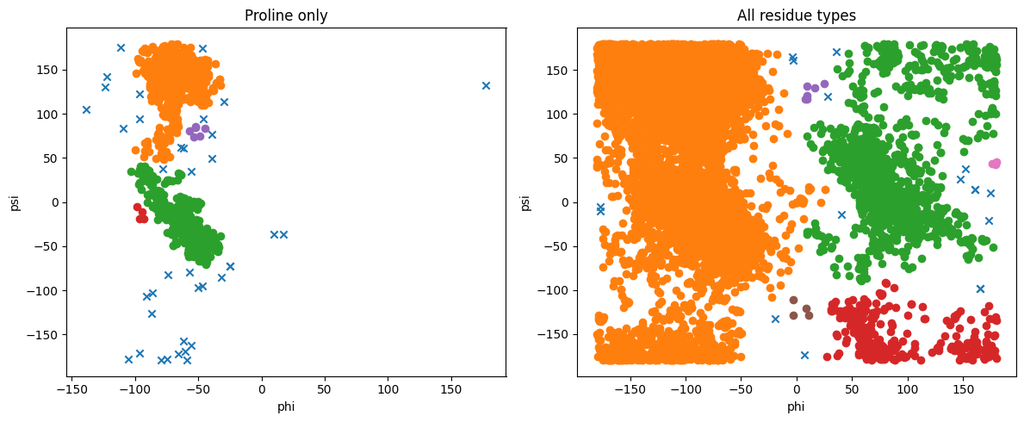

```python
proline_df = proteins_df[proteins_df["residue name"] == "PRO"].copy()
X_proline = proline_df[["phi", "psi"]].values

proline_eps = 8
proline_min_samples = 3

db_pro = DBSCAN(eps=proline_eps, min_samples=proline_min_samples)
pro_labels = db_pro.fit_predict(X_proline)

proline_df["pro_cluster"] = pro_labels

fig, axes = plt.subplots(1, 2, figsize=(12, 5))

ax = axes[0]
unique_pro = np.unique(pro_labels)

for label in unique_pro:
    subset = proline_df[proline_df["pro_cluster"] == label]
    if label == -1:
        ax.scatter(subset["phi"], subset["psi"], marker="x")
    else:
        ax.scatter(subset["phi"], subset["psi"])

ax.set_title("Proline only")
ax.set_xlabel("phi")
ax.set_ylabel("psi")


ax = axes[1]
unique_all = np.unique(proteins_df["dbscan_cluster"])

for label in unique_all:
    subset = proteins_df[proteins_df["dbscan_cluster"] == label]
    if label == -1:
        ax.scatter(subset["phi"], subset["psi"], marker="x")
    else:
        ax.scatter(subset["phi"], subset["psi"])

ax.set_title("All residue types")
ax.set_xlabel("phi")
ax.set_ylabel("psi")

plt.tight_layout()
plt.show()
```